# Introduction to the pedtools package

Magnus Dehli Vigeland

2026-06-19

The purpose of this vignette is to show how to work with pedigrees and marker data in **pedtools**.

To get started, install the current CRAN version of the package:

```r
install.packages("pedtools")
```

Alternatively, you may want the latest development version from GitHub:

```r
devtools::install_github("magnusdv/pedtools")
```

Now you should be able to load **pedtools**.

```r
library(pedtools)
```

# 1 Pedigrees

In **pedtools** and all other pedsuite packages, pedigrees are stored as `ped` objects. We start by explaining briefly what these objects look like, and their basic constructor. If you are reading this vignette simply to learn how to create a particular pedigree, you may want to skip ahead to section 1.3 where we describe practical shortcuts to common pedigree structures.

## 1.1 The `ped` class

**The constructor function**  
The most direct way to create a pedigree in **pedtools** is with the `ped()` constructor. This takes as input 4 vectors of equal length:

- `id` : individual ID labels (numeric or character)
- `fid` : id of the fathers (0 if not included)
- `mid` : id of the mothers (0 if not included)
- `sex` : gender codes, with entries 0 (unknown), 1 (male) or 2 (female)

In other words, the j’th pedigree member has label `id[j]`, father `fid[j]`, mother `mid[j]`, and gender given by `sex[j]`.

For example, the following creates a family *trio*, i.e. father, mother and child:

```r
ped(id = 1:3, fid = c(0,0,1), mid = c(0,0,2), sex = c(1,2,2))
```

```
#>  id fid mid sex
#>   1   *   *   1
#>   2   *   *   2
#>   3   1   2   2
```

In this example the child (`id=3`) is female, since the associated entry in `sex` is 2. Note that missing parents are printed as `*`. Individuals without parents are called *founders* of the pedigree, while the *nonfounders* have both parents specified. It is not allowed to have exactly one parent.

Instead of numerical labels as above, we could have used character strings. Let us create the trio again, with more informative labels, and store it in a variable named `trio`.

```r
trio = ped(id = c("fa", "mo", "girl"), fid = c("","","fa"), mid = c("","","mo"), sex = c(1,2,2))
trio
```

```
#>    id fid mid sex
#>    fa   *   *   1
#>    mo   *   *   2
#>  girl  fa  mo   2
```

The special strings `"0"`, `""` and `NA` are all interpreted as a missing parent.

**How pedigrees are stored internally**  
From the way it is printed, the object `trio` appears to be a data frame, but this is not exactly true. Rather it is an object of class `ped`, which is basically a list. We can see the actual content of `trio` by unclassing it:

```r
unclass(trio)
```

```
#> $ID
#> [1] "fa"   "mo"   "girl"
#>
#> $FIDX
#> [1] 0 0 1
#>
#> $MIDX
#> [1] 0 0 2
#>
#> $SEX
#> [1] 1 2 2
#>
#> $FAMID
#> [1] ""
#>
#> $UNBROKEN_LOOPS
#> [1] FALSE
#>
#> $LOOP_BREAKERS
#> NULL
#>
#> $FOUNDER_INBREEDING
#> NULL
#>
#> $MARKERS
#> NULL
```

In most cases it is not recommended for regular users to interact directly with the internal slots of a `ped`, since this can have unfortunate consequences unless you know exactly what you are doing. Instead, one should use accessor functions like `labels()`, `getMarkers()` and `founderInbreeding()`. The most important accessors are described within this vignette, while others are documented in the help page `?ped_utils`.

## 1.2 Basic pedigree plots

To plot a pedigree, simply use `plot()`.

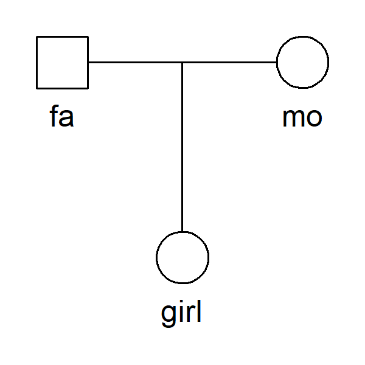

```r
plot(trio)
```

Under the hood, `pedtools::plot()` imports the excellent alignment algorithm from the **kinship2** package. The plotting itself is done within **pedtools**, which has some advantages over **kinship2**, including the ability to plot singletons. A wealth of plot options are available. An overview can be found in the documentation `?plot.ped`, but a couple of quick examples should get you started. Here is a demonstration of symbol colours and styles:

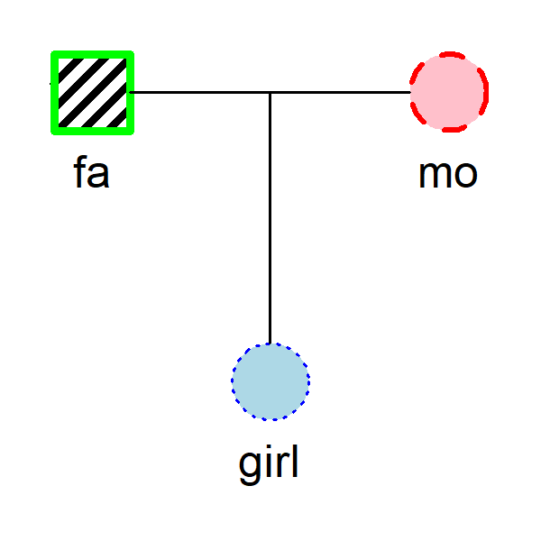

```r
plot(trio, hatched = "fa", hatchDensity = 15,
     fill = c(mo = "pink", girl = "lightblue"),
     col = c("green", "red", "blue"),
     lwd = 3:1, lty = 1:3)
```

And here is an example of how to put text annotation around the symbols:

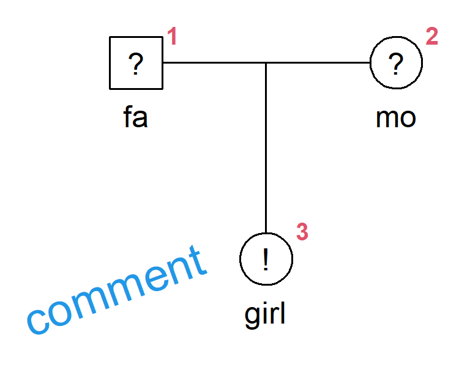

```r
plot(trio, margin = c(1,3,1,1),
     textAnnot = list(
       topright = list(1:3, cex = 0.8, col = 2, font = 2, offset = 0.1),
       left     = list(c(girl = "comment"), cex = 1.5, col = 4, offset = 1, srt = 20),
       inside   = c("?", "?", "!")))
```

See Section 2.2 for how to add marker genotypes to pedigree plots.

## 1.3 Built-in pedigree structures

Rather than using the `ped()` function directly, it is usually quicker and safer to build pedigrees step by step, applying the arsenal of utility functions offered by **pedtools**. A typical workflow is as follows:

1. Choose one of the basic pedigree structures as starting point.
2. Add/remove individuals as needed.
3. Modify attributes like genders and labels.

You will find several examples below, but first let us list the available tools for each of the 3 steps.

**Basic pedigrees**  
The following pedigree structures serve as starting points for pedigree constructions. For parameters and details, see `?ped_basic`.

- `singleton()`, a pedigree consisting of a single individual
- `singletons()`, a list of unrelated singletons
- `nuclearPed()`, a nuclear pedigree (parents+children)
- `halfSibPed()`, two sibships with one parent in common
- `linearPed()`, a straight line of successors
- `avuncularPed()`, uncle-nephew and similar relationships
- `cousinPed()`, cousins of specified degree/removal
- `halfCousinPed()`, half cousins of specified degree/removal
- `ancestralPed()`, a family tree containing the ancestors of a single person

There are also more specialized structures, including double cousins, selfing pedigrees, and consecutive matings between full siblings. Look them up in `?ped_complex` if you are interested.

**Add/remove/extract individuals**  
The functions below are used to modify an existing `ped` object by adding/removing individuals, or extracting a sub-pedigree. For details, see `?ped_modify`.

- `addChildren()`, with special cases `addSon()`, `addDaughter()`, `addChild()`
- `addParents()`
- `removeIndividuals()`
- `branch()`
- `subset()`

**Edit labels and attributes**  
The following functions modify various attributes of a `ped` object. See `?ped_modify` for parameters and details.

- `setSex()`
- `swapSex()`
- `relabel()`

## 1.4 Examples of pedigree construction

### Example 1: Trio

As our first example we will recreate the `trio` pedigree without using the `ped()` constructor. To give a hint of the flexibility, we show 3 alternative ways to code this.

**Alternative A**  
The obvious starting point is `nuclearPed()`, with `nch = 1` to indicate 1 child. By default, this creates a trio with numeric labels (father=1; mother=2; child=3) and a male child. Hence we fix the gender with `swapSex()`, and edit the labels with `relabel()`:

```r
trio2 = nuclearPed(nch = 1)
trio2 = swapSex(trio2, ids = 3)
trio2 = relabel(trio2, new = c("fa", "mo", "girl"))
```

Pedigree building with **pedtools** works very well with R’s pipe operator `|>`. For example, the above commands could be written in one chain like this:

```r
trio2 = nuclearPed(1) |>
  swapSex(3) |>
  relabel(new = c("fa", "mo", "girl"))
```

**Alternative B**  
Even quicker than the pipe version is the following one-liner, where all details are specified directly in the call to `nuclearPed()`.

```r
trio3 = nuclearPed(father = "fa", mother = "mo", children = "girl", sex = 2)
```

**Alternative C**  
Here is another possibility. We start by creating the father as a singleton, and then add the daughter:

```r
trio4 = singleton("fa") |>
  addDaughter("fa", id = "girl") |>
  relabel(old = "1", new = "mo")
```

```
#> Creating new mother: 1
```

Note that `addDaughter()` automatically created the mother as “1”, so we needed to relabel her.

### Example 2: An inbred child

This time we will create this inbred family:

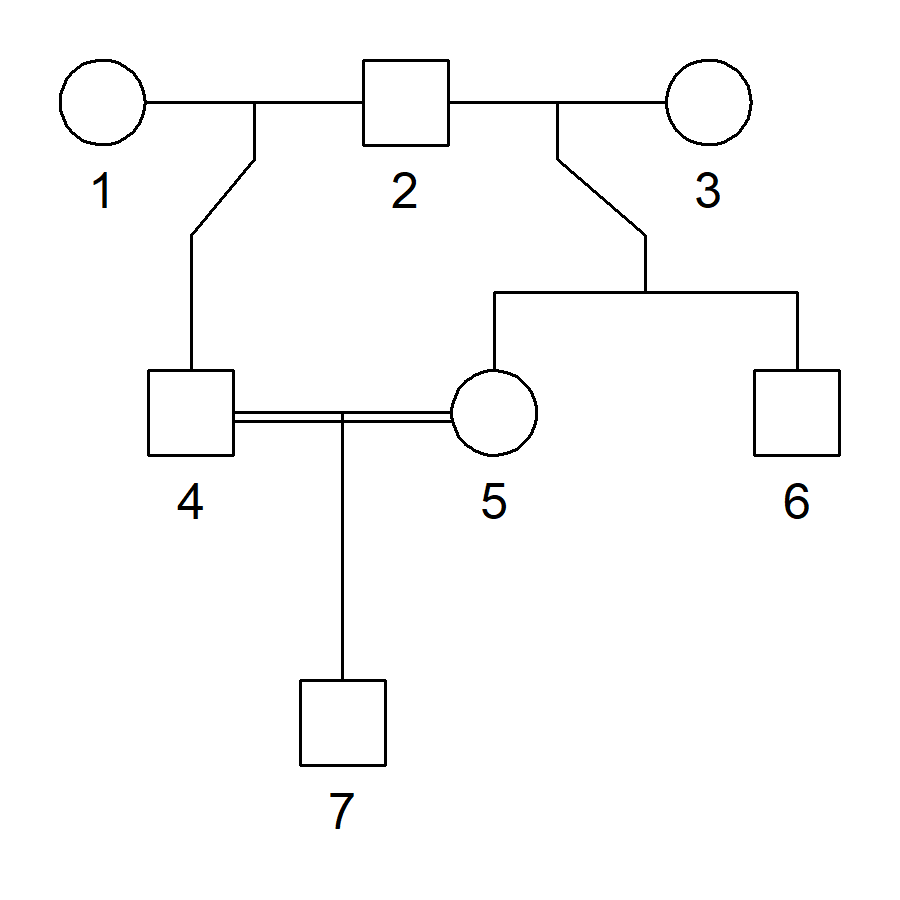

**Alternative A**  
One approach is to first create the pedigree consisting of individuals 1-6, with `halfSibPed()`, and then use `addSon()` to add the inbred child.

```r
x1 = halfSibPed(nch1 = 1, nch2 = 2, sex1 = 1, sex2 = 2:1) |>
  addSon(parents = 4:5)
```

**Alternative B**  
We could also view the half siblings 4 and 5 as half cousins of degree 0. The `halfCousinPed()` function accepts an option `child = TRUE` adding an inbred child. The labels will be different with this approach, so we need to relabel at the end.

```r
x2 = halfCousinPed(0, child = T) |>
  addSon(parents = 2:3) |>
  relabel()
```

We can see that the two alternatives produce the same result:

```r
identical(x1, x2)
```

```
#> [1] TRUE
```

### 1.4.1 Example 3: A complex family tree

Here we consider the family tree below, extending both upwards and downwards from a single person. We will use this example to demonstrate the `mergePed()` function, which “glues” together two pedigrees by the indicated members.

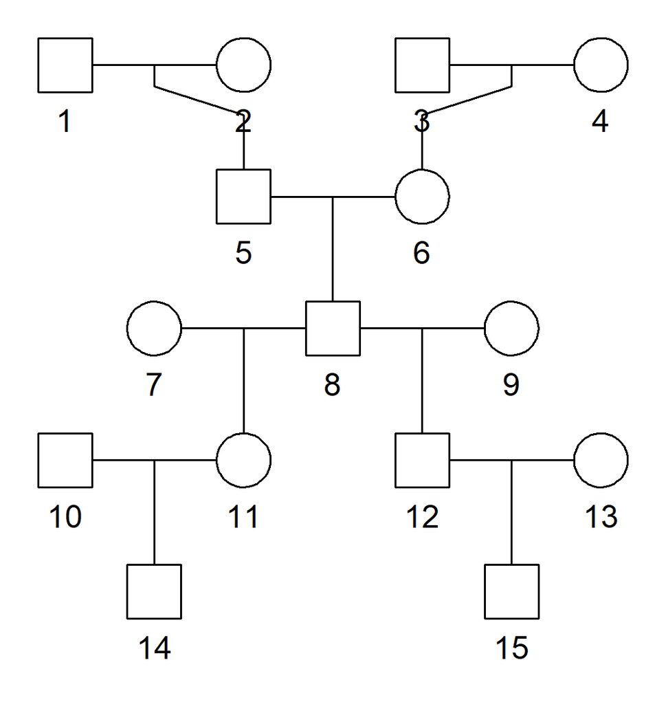

```r
# Top part
x = ancestralPed(g = 2) # bottom person is "7"

# Bottom part
y = halfCousinPed(degree = 1) # top person is "2"
y = swapSex(y, 4)
```

```
#> Changing sex of spouses as well: 5
```

```r
# Merge
z = mergePed(x, y, by = c("7" = "2"), relabel = TRUE)
```

Note the argument `by = c("7" = "2")`, which means that individual “7” in `x` should be identified with “2” in `y`. As seen in the plot below, this individual ends up as “8” after relabelling in the final result.

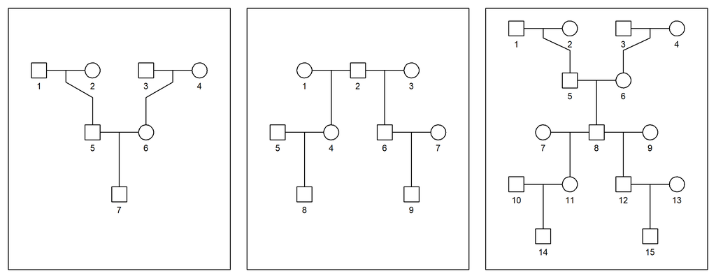

```r
plotPedList(list(x, y, z))
```

## 1.5 Pedigree subsets

Many situations call for selecting all pedigree members sharing some property, e.g., all females, or all descendants of some person. Several utilities in **pedtools** exist to help with such tasks. Generally these come in two flavours: 1) members with certain *global* property, and 2) members with a certain relationship to a given individual.

**Pedigree members with a certain property**  
Each of the following functions returns a vector specifying the members with the given property.

- `founders()`
- `nonfounders()`
- `leaves()`
- `males()`
- `females()`
- `typedMembers()`
- `untypedMembers()`

By default, the output of these functions is a character vector containing ID labels. However, adding the option `internal = TRUE` will give you an integer vector instead, reporting the internal indices of the members. This is frequently used in the source code of **pedtools**, but is usually not intended for end users of the package.

**Relatives of a given individual**  
The functions below take as input a `ped` object and the label of a single member. They return a vector of all members with the given relation to that individual.

- `father()`
- `mother()`
- `parents()`
- `grandparents()`
- `children()`
- `spouses()`
- `siblings()`
- `niblings()` (= nieces and nephews)
- `piblings()` (= aunts and uncles)
- `ancestors()`
- `descendants()`
- `unrelated()`

# 2 Markers

The other main theme of the **pedtools** package (pedigrees being the first) are marker genotypes.

## 2.1 Creating marker objects

Marker objects created with the `marker()` function. For example, the following command makes an empty marker associated with the `trio` pedigree:

```r
marker(trio)
```

```
#>    id  <NA>
#>    fa   -/-
#>    mo   -/-
#>  girl   -/-
#> * * * * * *
#> Position: NA
#> Mut model: none
#> Frequencies:
#>    1   2
#>  0.5 0.5
```

As shown in the output, the marker is indeed empty: All pedigree members have missing genotypes, and there is no assigned name or position. By default, markers are diallelic, with alleles 1 and 2, with equal frequencies. For a more interesting example, let us make a SNP named “snp1”, with alleles “A” and “B”. The father is homozygous “A/A”, while the mother is heterozygous. We store it in a variable `m1` for later use.

```r
m1 = marker(trio, fa = "A/A", mo = "A/B", name = "snp1")
```

This illustrates several points. Firstly, individual genotypes may be specified using the ID labels. The different alleles occurring in the genotypes is interpreted as the complete set of alleles for the marker. Finally, these are assigned equal frequencies. Of course, this behaviour can be overridden, by declaring alleles frequencies explicitly:

```r
marker(trio, fa = "A/A", mo = "A/B", afreq = c(A = .2, B = .3, C = .5))
```

```
#>    id  <NA>
#>    fa   A/A
#>    mo   A/B
#>  girl   -/-
#> * * * * * *
#> Position: NA
#> Mut model: none
#> Frequencies:
#>    A   B   C
#>  0.2 0.3 0.5
```

The markers chromosome can be declared using the `chrom` argument, and similarly its position by `posMb` (megabases). Markers with unknown chromosome are treated as autosomal. To define an X-linked marker, put `chrom = "X"`. the fact that males are hemizygous on X (i.e. they have only one allele) is reflected in the printout of such markers:

```r
m2 = marker(trio, fa = "A/A", mo = "A/B", chrom = "X", name = "snpX")
m2
```

```
#>    id  snpX
#>    fa     A
#>    mo   A/B
#>  girl   -/-
#> * * * * * *
#> Position: chr = X, Mb = NA
#> Mut model: none
#> Frequencies:
#>    A   B
#>  0.5 0.5
```

A side note: It may come as a surprise that you don’t need quotes around the ID labels (which are characters!) in the above commands. This is because `marker()` uses *non-standard evaluation (NSE)*, a peculiarity of the R language which often leads to less typing and more readable code.[^1] Unfortunately, this doesn’t work with numerical ID labels. Thus to assign a genotype to someone labelled “1” you need quotes, as in `marker(trio, "1" = "A/A")`.

## 2.2 Plotting pedigrees with marker data

Including marker data in a pedigree plot is straightforward:

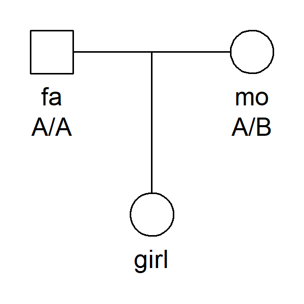

```r
plot(trio, marker = m1)
```

The appearance of the genotypes can be tweaked in various ways, as documented in `?plot.ped`. Here’s an example:

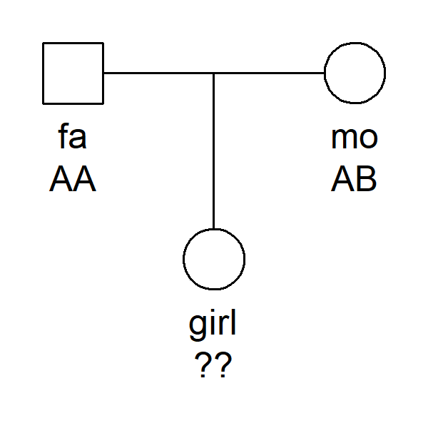

```r
plot(trio, marker = m1, showEmpty = T, missing = "?", sep = "")
```

## 2.3 Markers attached to pedigrees

In most applications it is useful to *attach* markers to their `ped` object. In particular for bigger projects with many markers, this makes it easier to manipulate the dataset as a unit.

To attach a marker object `m` (which could be a list of several markers) to a pedigree `x`, there are two main options:

- `setMarkers(x, m)`
- `addMarkers(x, m)`

The difference between these is that `setMarkers()` replaces all existing markers, while `addMarkers()` appends `m` to the existing ones. In our `trio` example the two are equivalent since there are no existing markers.

```r
trio = setMarkers(trio, list(m1, m2))
trio
```

```
#>    id fid mid sex snp1 snpX
#>    fa   *   *   1  A/A    A
#>    mo   *   *   2  A/B  A/B
#>  girl  fa  mo   2  -/-  -/-
```

```r
nuclearPed(1) |>
  addMarker(name = "myMarker", alleles = c("a", "b", "c")) |>
  setGenotype(id = 3, geno = "a/c")
```

```
#>  id fid mid sex myMarker
#>   1   *   *   1      -/-
#>   2   *   *   2      -/-
#>   3   1   2   1      a/c
```

**Selecting and removing attached markers**  
Four closely related functions functions are useful for manipulating markers attached to a pedigree:

- `selectMarkers()`, returns a `ped` object where only the indicated markers are retained
- `removeMarkers()`, returns a `ped` object where the indicated markers are removed
- `getMarkers()`, returns a list of the indicated markers
- `whichMarkers()`, returns the indices of the indicated markers

All of these have exactly the same arguments, described in more detail in `?marker_select`. Let us do a couple of examples here. Recall that by now, our `trio` has two attached markers; the first is called “snp1”, and the other is on the X chromosome.

```r
whichMarkers(trio, chrom = "X")
```

```
#> [1] 2
```

```r
selectMarkers(trio, markers = "snp1")
```

```
#>    id fid mid sex snp1
#>    fa   *   *   1  A/A
#>    mo   *   *   2  A/B
#>  girl  fa  mo   2  -/-
```

## 2.4 Accessing and modifying individual markers

Internally, a marker object is stored as a matrix with two columns (one for each allele) and one row for each pedigree member. The matrix is numeric (for computational convenience) while the allele labels and other meta information are added as *attributes*. The most important of these are:

- `alleles` : The allele labels, stored as a character vector.
- `afreq` : The allele frequencies, in the same order as the alleles. An error is issued if the frequencies do not sum to 1 after rounding to 3 decimals.
- `name` : The marker name, which can be any character string not consisting solely of digits.
- `chrom` : The chromosome name. This can be given as an integer, but is always converted to character. The special values “23” and “X” are recognized as the human X chromosome, which affects the way genotypes are printed.
- `posMb` : Chromosomal position given in megabases.

In addition to those listed above, there are two more attributes: `pedmembers` and `sex`. They store the ID labels and genders of the pedigree associated with the marker, and are only used to empower the printing method of marker objects.

**Marker accessor functions**  
For each marker attribute listed above, there is a corresponding function with the same name for retrieving its content. These functions take as input either a `marker` object, or a `ped` object together with the name (or index) of an attached marker. This may sound a bit confusing, but a few examples will make it clear!

Recall that our marker “snp1” exists in two copies: One is stored in the variable `m1`, while the other is attached to `trio`. In both cases we can extract the allele frequencies with the function `afreq()`.

```r
afreq(m1)
```

```
#>   A   B
#> 0.5 0.5
```

```r
afreq(trio, marker = "snp1")
```

```
#>   A   B
#> 0.5 0.5
```

We can also *modify* the frequencies using this syntax. To avoid confusion about the allele order, the frequencies must be named with the allele labels (just as in the output of `afreq()` above).

```r
afreq(trio, marker = "snp1") = c(A = 0.9, B = 0.1)
```

In addition to the functions getting and setting marker attributes, there is one more important marker accessor, namely `genotype()`. This returns the genotype of a specified individual, and can also be used to modify genotypes. As the others, it can be applied to marker objects directly, or to pedigrees with attached markers. Here we show a few examples of the latter type:

```r
# Girl is not genotyped
genotype(trio, "snpX", id = "girl")
```

```
#> [1] NA NA
```

```r
# Set genotype
genotype(trio, "snpX", id = "girl") = "A/A"

# Inspect the result
trio
```

```
#>    id fid mid sex snp1 snpX
#>    fa   *   *   1  A/A    A
#>    mo   *   *   2  A/B  A/B
#>  girl  fa  mo   2  -/-  A/A
```

## 2.5 Getting/setting/modifying many markers simultaneously

Several functions in **pedtools** are indented for modifying many (or all) markers at the same time. Their purpose and typical use cases are summarised in the table below. The argument `x` always denotes a `ped` object.

[output not shown]

[^1]: You may have come across NSE before, for instance when using `subset()` on a data.frame. To learn more about NSE, I recommend this book chapter by Hadley Wickham:  
    http://adv-r.had.co.nz/Computing-on-the-language.html